```python
from google.colab import drive
drive.mount('/content/drive')
```

# Import Data

```python
import pandas as pd
import numpy as np
import matplotlib.pyplot as plt
import seaborn as sns

df=pd.read_csv('/content/drive/My Drive/Public Data/Lotto/Data/Lotto.csv',parse_dates=["datetime"],encoding='UTF-8',engine='python')
df.tail()
```

|  | round | datetime | 1 | 2 | 3 | 4 | 5 | 6 | bonus | Unnamed: 9 | Unnamed: 10 | Unnamed: 11 |
| --- | --- | --- | --- | --- | --- | --- | --- | --- | --- | --- | --- | --- |
| 910 | 3.0 | 2002-12-21 | 11.0 | 16.0 | 19.0 | 21.0 | 27.0 | 31.0 | 30.0 | NaN | NaN | NaN |
| 911 | 2.0 | 2002-12-14 | 9.0 | 13.0 | 21.0 | 25.0 | 32.0 | 42.0 | 2.0 | NaN | NaN | NaN |
| 912 | 1.0 | 2002-12-07 | 10.0 | 23.0 | 29.0 | 33.0 | 37.0 | 40.0 | 16.0 | NaN | NaN | NaN |
| 913 | NaN | NaT | NaN | NaN | NaN | NaN | NaN | NaN | NaN | NaN | NaN | NaN |
| 914 | NaN | NaT | NaN | NaN | NaN | NaN | NaN | NaN | NaN | NaN | NaN | NaN |

# Handling Datetime type

```python
import datetime

df=df[['round','datetime','1','2','3','4','5','6','bonus']]

df['year']=df['datetime'].dt.year
df['month']=df['datetime'].dt.month
df['day']=df['datetime'].dt.day
df.drop(['datetime'],axis=1,inplace=True)

df.drop([913,914],inplace=True)
for col in df.columns:
  df[col]=df[col].astype(int)
df.head()
```

|  | round | 1 | 2 | 3 | 4 | 5 | 6 | bonus | year | month | day |
| --- | --- | --- | --- | --- | --- | --- | --- | --- | --- | --- | --- |
| 0 | 913 | 6 | 14 | 16 | 21 | 27 | 37 | 40 | 2020 | 5 | 30 |
| 1 | 912 | 5 | 8 | 18 | 21 | 22 | 38 | 10 | 2020 | 5 | 23 |
| 2 | 911 | 4 | 5 | 12 | 14 | 32 | 42 | 35 | 2020 | 5 | 16 |
| 3 | 910 | 1 | 11 | 17 | 27 | 35 | 39 | 31 | 2020 | 5 | 9 |
| 4 | 909 | 7 | 24 | 29 | 30 | 34 | 35 | 33 | 2020 | 5 | 2 |

**sort the dataframe as ascending order by date**

```python
df=df.sort_values(['year','month','day'])
df.head()
```

|  | round | 1 | 2 | 3 | 4 | 5 | 6 | bonus | year | month | day |
| --- | --- | --- | --- | --- | --- | --- | --- | --- | --- | --- | --- |
| 912 | 1 | 10 | 23 | 29 | 33 | 37 | 40 | 16 | 2002 | 12 | 7 |
| 911 | 2 | 9 | 13 | 21 | 25 | 32 | 42 | 2 | 2002 | 12 | 14 |
| 910 | 3 | 11 | 16 | 19 | 21 | 27 | 31 | 30 | 2002 | 12 | 21 |
| 909 | 4 | 14 | 27 | 30 | 31 | 40 | 42 | 2 | 2002 | 12 | 28 |
| 908 | 5 | 16 | 24 | 29 | 40 | 41 | 42 | 3 | 2003 | 1 | 4 |

**Get Lotto numbers for each week**

```python
train=df[['1','2','3','4','5','6','bonus']]
train.rename(columns={'bonus':'7'},inplace=True)
train.head()
```

|  | 1 | 2 | 3 | 4 | 5 | 6 | 7 |
| --- | --- | --- | --- | --- | --- | --- | --- |
| 912 | 10 | 23 | 29 | 33 | 37 | 40 | 16 |
| 911 | 9 | 13 | 21 | 25 | 32 | 42 | 2 |
| 910 | 11 | 16 | 19 | 21 | 27 | 31 | 30 |
| 909 | 14 | 27 | 30 | 31 | 40 | 42 | 2 |
| 908 | 16 | 24 | 29 | 40 | 41 | 42 | 3 |

**Show the numbers distribution**

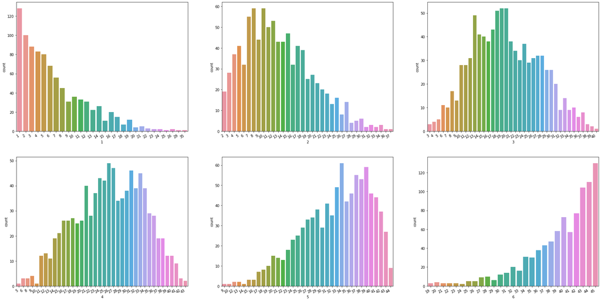

```python
fig, axes= plt.subplots(nrows=2,ncols=3)
fig.set_size_inches(30,15)
for axe in axes[0]:
  plt.sca(axe)
  plt.xticks(rotation=30,ha='right')

for axe in axes[1]:
  plt.sca(axe)
  plt.xticks(rotation=30,ha='right')

sns.countplot(data=train,x='1',ax=axes[0][0])
sns.countplot(data=train,x='2',ax=axes[0][1])
sns.countplot(data=train,x='3',ax=axes[0][2])
sns.countplot(data=train,x='4',ax=axes[1][0])
sns.countplot(data=train,x='5',ax=axes[1][1])
sns.countplot(data=train,x='6',ax=axes[1][2])
```

**we can see 6 numbers in a week are sorted by ascending order.**  
**so first number has lots of lower number like 1,2,3.**  
**sixth number has lots of higher nubmer like 45,44,43.**  
**we sholud shuffle this.**

```python
for i in range(train.shape[0]):
  np.random.shuffle(train.iloc[i][:6])
train.head()
```

|  | 1 | 2 | 3 | 4 | 5 | 6 | 7 |
| --- | --- | --- | --- | --- | --- | --- | --- |
| 912 | 40 | 23 | 33 | 10 | 29 | 37 | 16 |
| 911 | 25 | 42 | 13 | 21 | 32 | 9 | 2 |
| 910 | 11 | 16 | 27 | 19 | 31 | 21 | 30 |
| 909 | 31 | 42 | 14 | 30 | 40 | 27 | 2 |
| 908 | 24 | 40 | 29 | 41 | 16 | 42 | 3 |

**After shuffling, show the numbers distribution**

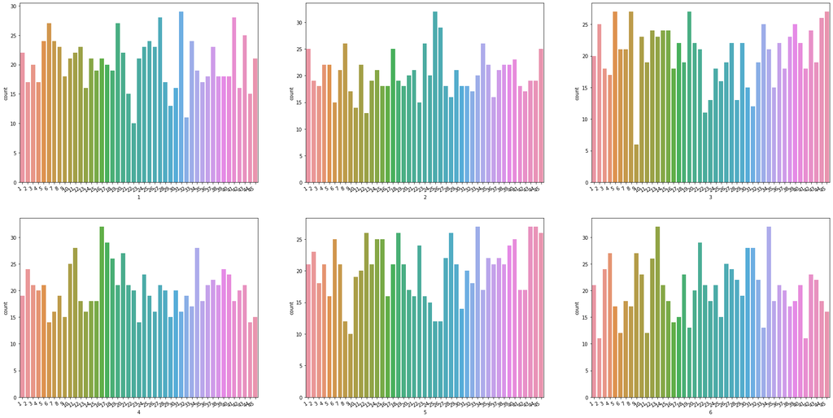

```python
fig, axes= plt.subplots(nrows=2,ncols=3)
fig.set_size_inches(30,15)
for axe in axes[0]:
  plt.sca(axe)
  plt.xticks(rotation=30,ha='right')

for axe in axes[1]:
  plt.sca(axe)
  plt.xticks(rotation=30,ha='right')

sns.countplot(data=train,x='1',ax=axes[0][0])
sns.countplot(data=train,x='2',ax=axes[0][1])
sns.countplot(data=train,x='3',ax=axes[0][2])
sns.countplot(data=train,x='4',ax=axes[1][0])
sns.countplot(data=train,x='5',ax=axes[1][1])
sns.countplot(data=train,x='6',ax=axes[1][2])
```

**as we can see, 6 number has a quite silmilar distribution.**  
**now we can try to predict.**  
**Let's make lag feature first.**

```python
for i in range(1,6):
  for j in range(1,8):
    train[str(i)+'_lag_'+str(j)]=train[str(j)].shift(i)
train.drop([0,1,2,3,4],inplace=True)
train.reset_index(drop=True, inplace=True)
for col in train.columns:
  train[col]=train[col].astype(int)
train.head()
```

|  | 1 | 2 | 3 | 4 | 5 | 6 | 7 | 1_lag_1 | 1_lag_2 | 1_lag_3 | 1_lag_4 | 1_lag_5 | 1_lag_6 | 1_lag_7 | 2_lag_1 | 2_lag_2 | 2_lag_3 | 2_lag_4 | 2_lag_5 | 2_lag_6 | 2_lag_7 | 3_lag_1 | 3_lag_2 | 3_lag_3 | 3_lag_4 | 3_lag_5 | 3_lag_6 | 3_lag_7 | 4_lag_1 | … |
| --- | --- | --- | --- | --- | --- | --- | --- | --- | --- | --- | --- | --- | --- | --- | --- | --- | --- | --- | --- | --- | --- | --- | --- | --- | --- | --- | --- | --- | --- | --- |
| 0 | 18 | 12 | 17 | 31 | 6 | 32 | 21 | 10 | 23 | 30 | 20 | 14 | 18 | 41 | 43 | 30 | 40 | 6 | 38 | 39 | 26 | 3 | 19 | 12 | 32 | 35 | 13 | 29 | 9 | … |
| 1 | 8 | 17 | 5 | 6 | 4 | 39 | 25 | 18 | 12 | 17 | 31 | 6 | 32 | 21 | 10 | 23 | 30 | 20 | 14 | 18 | 41 | 43 | 30 | 40 | 6 | 38 | 39 | 26 | 3 | … |
| 2 | 5 | 17 | 42 | 33 | 18 | 13 | 44 | 8 | 17 | 5 | 6 | 4 | 39 | 25 | 18 | 12 | 17 | 31 | 6 | 32 | 21 | 10 | 23 | 30 | 20 | 14 | 18 | 41 | 43 | … |
| 3 | 27 | 7 | 29 | 8 | 36 | 43 | 6 | 5 | 17 | 42 | 33 | 18 | 13 | 44 | 8 | 17 | 5 | 6 | 4 | 39 | 25 | 18 | 12 | 17 | 31 | 6 | 32 | 21 | 10 | … |
| 4 | 43 | 26 | 4 | 44 | 21 | 2 | 16 | 27 | 7 | 29 | 8 | 36 | 43 | 6 | 5 | 17 | 42 | 33 | 18 | 13 | 44 | 8 | 17 | 5 | 6 | 4 | 39 | 25 | 18 | … |

**i_lag_j means j_th number which is i_th week before.**

```python
train.shape
```

```
(888, 42)
```

# Modeling part

```python
from lightgbm import LGBMRegressor
import lightgbm as lgb
from sklearn.model_selection import train_test_split

for col in train.columns:
  train[col]=train[col].astype('category')

models=[i for i in range(7)]
params = {'learning_rate': 0.01,
          'max_depth': 16,
          'boosting': 'gbdt',
          'objective': 'multiclass',
          'num_class' : 46,
          'metric': 'multiclass',
          'num_leaves': 144,
          'feature_fraction': 0.9,
          'bagging_fraction': 0.7,
          'bagging_freq': 5,
          'seed':2018}
x_train=train.drop(['1','2','3','4','5','6','7'],axis=1).iloc[:800]
y_train=[train[str(i)][:800] for i in range(1,8)]
x_test=train.drop(['1','2','3','4','5','6','7'],axis=1).iloc[800:]
y_test=[train[str(i)][800:] for i in range(1,8)]
for i in range(0,7):
  lgb_train=lgb.Dataset(x_train,y_train[i])
  lgb_test=lgb.Dataset(x_test,y_test[i])
  models[i]=lgb.train(params, lgb_train, 1000, lgb_test, verbose_eval=100)
```

```
[100]	valid_0's multi_logloss: 3.89143
[200]	valid_0's multi_logloss: 3.90487
[300]	valid_0's multi_logloss: 3.92273
[400]	valid_0's multi_logloss: 3.94892
[500]	valid_0's multi_logloss: 3.96131
[600]	valid_0's multi_logloss: 3.98035
[700]	valid_0's multi_logloss: 3.99439
[800]	valid_0's multi_logloss: 4.01819
[900]	valid_0's multi_logloss: 4.03544
[1000]	valid_0's multi_logloss: 4.04861
[100]	valid_0's multi_logloss: 3.83425
[200]	valid_0's multi_logloss: 3.83815
[300]	valid_0's multi_logloss: 3.83732
[400]	valid_0's multi_logloss: 3.85492
[500]	valid_0's multi_logloss: 3.86242
[600]	valid_0's multi_logloss: 3.86798
[700]	valid_0's multi_logloss: 3.88402
[800]	valid_0's multi_logloss: 3.88923
[900]	valid_0's multi_logloss: 3.90619
[1000]	valid_0's multi_logloss: 3.91676
[100]	valid_0's multi_logloss: 3.85064
[200]	valid_0's multi_logloss: 3.86775
[300]	valid_0's multi_logloss: 3.89135
[400]	valid_0's multi_logloss: 3.91856
[500]	valid_0's multi_logloss: 3.93482
[600]	valid_0's multi_logloss: 3.94901
[700]	valid_0's multi_logloss: 3.96558
[800]	valid_0's multi_logloss: 3.98706
[900]	valid_0's multi_logloss: 4.00635
[1000]	valid_0's multi_logloss: 4.02585
[100]	valid_0's multi_logloss: 3.86642
[200]	valid_0's multi_logloss: 3.88821
[300]	valid_0's multi_logloss: 3.9062
[400]	valid_0's multi_logloss: 3.93691
[500]	valid_0's multi_logloss: 3.95973
[600]	valid_0's multi_logloss: 3.98571
[700]	valid_0's multi_logloss: 4.00791
[800]	valid_0's multi_logloss: 4.03139
[900]	valid_0's multi_logloss: 4.05369
[1000]	valid_0's multi_logloss: 4.0701
```

[output cut: 15 more lines]

```
[600]	valid_0's multi_logloss: 3.90028
[700]	valid_0's multi_logloss: 3.91844
[800]	valid_0's multi_logloss: 3.93898
[900]	valid_0's multi_logloss: 3.95536
[1000]	valid_0's multi_logloss: 3.96788
[100]	valid_0's multi_logloss: 3.86893
[200]	valid_0's multi_logloss: 3.873
[300]	valid_0's multi_logloss: 3.88993
[400]	valid_0's multi_logloss: 3.88869
[500]	valid_0's multi_logloss: 3.89583
[600]	valid_0's multi_logloss: 3.90252
[700]	valid_0's multi_logloss: 3.90893
[800]	valid_0's multi_logloss: 3.92768
[900]	valid_0's multi_logloss: 3.94564
[1000]	valid_0's multi_logloss: 3.95976
```

```python
preds=[i for i in range(7)]
result=pd.DataFrame()
for i in range(i):
  preds[i]=np.argmax(models[i].predict(x_test),axis=1)
  result[i+1]=y_test[i]
  result[str(i+1)+'_pred']=preds[i]

score=0
for i in range(1,6):
  score+=np.mean(result[i]==result[str(i)+'_pred'])
score/=6
print("probability : {0}".format(score))
result.head()
```

```
probability : 0.013257575757575758
```

|  | 1 | 1_pred | 2 | 2_pred | 3 | 3_pred | 4 | 4_pred | 5 | 5_pred |
| --- | --- | --- | --- | --- | --- | --- | --- | --- | --- | --- |
| 800 | 1 | 7 | 24 | 17 | 29 | 5 | 12 | 16 | 44 | 37 |
| 801 | 27 | 31 | 24 | 28 | 18 | 44 | 20 | 43 | 36 | 40 |
| 802 | 18 | 20 | 12 | 5 | 40 | 6 | 26 | 25 | 39 | 43 |
| 803 | 24 | 8 | 34 | 1 | 29 | 40 | 7 | 40 | 38 | 41 |
| 804 | 21 | 28 | 33 | 14 | 15 | 27 | 38 | 34 | 8 | 14 |

**I checked how many numbers the model chose correctly with test data.**  
**as we can see only 1% of whole number is correct. Yes! it is also damn!**